# Heart Attack Analysis & Prediction_project

Daemon Wei

March 18, 2024

## 1. Introduction

Heart disease remains the leading cause of death globally, accounting for millions of deaths annually. The ability to accurately predict heart disease can lead to early diagnosis and intervention, significantly reducing the mortality rate associated with this condition. This project aims to leverage data science and machine learning techniques to analyze and predict the likelihood of heart attacks based on a wide range of factors including age, sex, chest pain type, resting blood pressure, serum cholesterol, and more.

Utilizing a dataset from Kaggle, this analysis will explore various features that may influence heart disease, implement several machine learning models to predict heart disease occurrence, and evaluate the performance of these models. The dataset includes diverse variables, offering a comprehensive insight into the factors that might contribute to heart disease.

Through this project, we aim to uncover significant predictors of heart disease, assess the predictive power of machine learning models in a medical context, and ultimately, contribute to the efforts of preventing heart disease by enabling early detection. This endeavor is not only a technical challenge but also a crucial step towards saving lives and improving health outcomes.

As we delve into the data and models, our goal is to present a clear, concise, and informative analysis that can serve as a foundation for further research and practical applications in the field of medical science and public health.

### 1.1 Examining the Project Topic

#### What is Heart Attack?

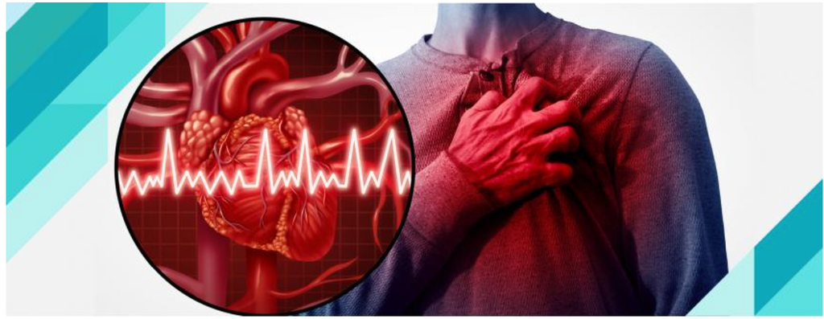

- The medical name of heart attack is “Myocardial infarction”.
- Heart attack in short; It is the occlusion of the vessel by plaque-like lesions filled with cholesterol and fat.
- The lesion is called abnormal conditions that occur in the organs where the disease is located.
- As a result of the blockage, the blood flow is completely cut off and a heart attack that can lead to death occurs.

#### How does a heart attack occur?

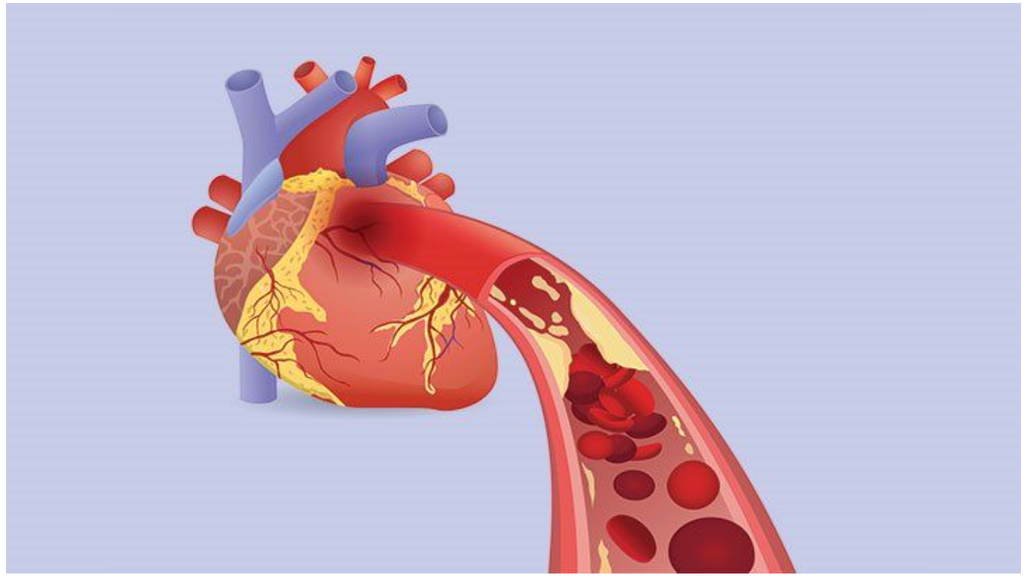

- The heart is like an efficient pump, tirelessly working to circulate blood throughout the body about 60 to 80 times a minute when we’re at rest. Just like any other part of the body, the heart itself needs a steady supply of nutrients and oxygen, which it gets through its very own set of blood vessels known as coronary arteries.
- Sometimes, these crucial arteries can have trouble with their blood flow due to blockages or narrowing, a condition known as coronary insufficiency. This issue can vary widely – it all depends on where the blockage is, how severe it is, and the specific arteries affected.
- For some, this might just mean chest pain that pops up during a workout or some physical task, but goes away once they take a break. However, in more serious cases, if a coronary artery gets suddenly completely blocked, it can trigger a heart attack. This often starts with intense chest pain and, in the worst-case scenario, can lead to sudden death.

### 1.2 Recognizing Variables In Dataset

**Variable definitions in the Dataset**

**Additional variable descriptions to help us**

1. age - age in years
2. sex - sex (1 = male; 0 = female)
3. cp - chest pain type (1 = typical angina; 2 = atypical angina; 3 = non-anginal pain; 0 = asymptomatic)
4. trestbps - resting blood pressure (in mm Hg on admission to the hospital)
5. chol - serum cholestoral in mg/dl
6. fbs - fasting blood sugar > 120 mg/dl (1 = true; 0 = false)
7. restecg - resting electrocardiographic results (1 = normal; 2 = having ST-T wave abnormality; 0 = hypertrophy)
8. thalach - maximum heart rate achieved
9. exang - exercise induced angina (1 = yes; 0 = no)
10. oldpeak - ST depression induced by exercise relative to rest
11. slope - the slope of the peak exercise ST segment (2 = upsloping; 1 = flat; 0 = downsloping)
12. ca - number of major vessels (0-3) colored by flourosopy
13. thal - 2 = normal; 1 = fixed defect; 3 = reversable defect
14. num - the predicted attribute - diagnosis of heart disease (angiographic disease status) (Value 0 = < diameter narrowing; Value 1 = > 50% diameter narrowing)

## 2. First Organization

#### 2.1.1 Basic Libraries

```r
library(corrplot)  # for the correlation plot
library(discrim)  # for linear discriminant analysis
library(corrr)   # for calculating correlation
library(knitr)   # to help with the knitting process
library(MASS)    # to assist with the markdown processes
library(tidyverse)   # using tidyverse and tidymodels for this project mostly
library(tidymodels)
library(ggplot2)   # for most of our visualizations
library(ggrepel)
library(rpart.plot)  # for visualizing trees
library(vip)         # for variable importance
library(janitor)     # for cleaning out our data
library(ranger)   # for building our randomForest
library(dplyr)     # for basic r functions
library(yardstick) # for measuring certain metrics
library(naniar)
tidymodels_prefer()
```

#### 2.2 Loading The Dataset

```r
Heart_data <- read_csv("data/heart.csv", show_col_types = FALSE)
Heart_data
```

```
## # A tibble: 303 × 14
##      age   sex    cp trtbps  chol   fbs restecg thalachh  exng oldpeak   slp
##    <dbl> <dbl> <dbl>  <dbl> <dbl> <dbl>   <dbl>    <dbl> <dbl>   <dbl> <dbl>
##  1    63     1     3    145   233     1       0      150     0     2.3     0
##  2    37     1     2    130   250     0       1      187     0     3.5     0
##  3    41     0     1    130   204     0       0      172     0     1.4     2
##  4    56     1     1    120   236     0       1      178     0     0.8     2
##  5    57     0     0    120   354     0       1      163     1     0.6     2
##  6    57     1     0    140   192     0       1      148     0     0.4     1
##  7    56     0     1    140   294     0       0      153     0     1.3     1
##  8    44     1     1    120   263     0       1      173     0     0       2
##  9    52     1     2    172   199     1       1      162     0     0.5     2
## 10    57     1     2    150   168     0       1      174     0     1.6     2
## # ℹ 293 more rows
## # ℹ 3 more variables: caa <dbl>, thall <dbl>, output <dbl>
```

## 3. Preparation for Exploratory Data Analysis(EDA)

### 3.1 Examining Missing Values

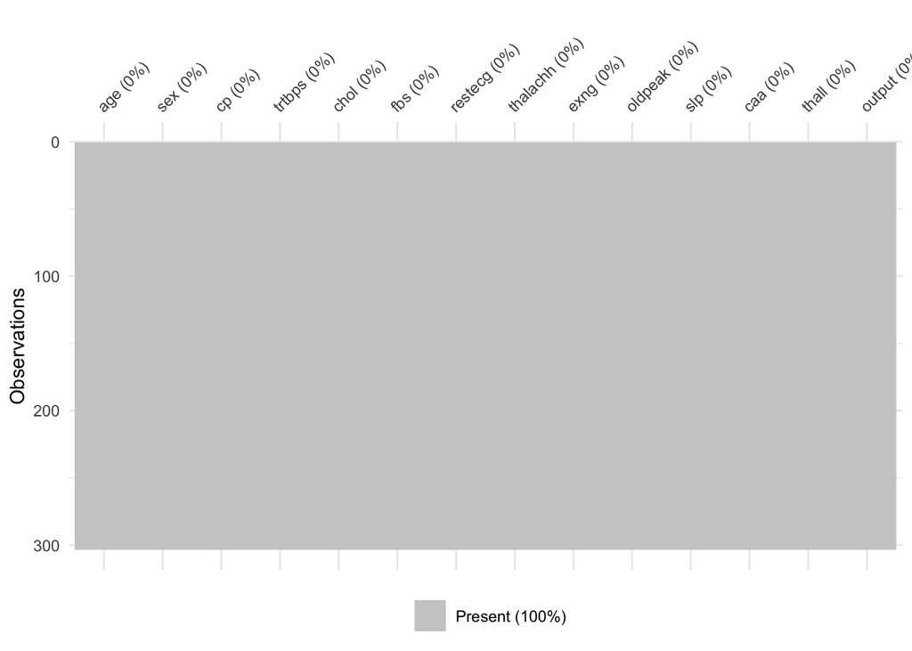

```r
vis_miss(Heart_data)
```

This plot shows us at a glance that there is no missing data in the whole dataset.

### 3.2 Examining Unique Values

```r
unique_number <- sapply(Heart_data, function(x) length(unique(x)))
unique_values_df <- data.frame("Total Unique Values" = unique_number)
rownames(unique_values_df) <- names(Heart_data)
print(unique_values_df)
```

```
##          Total.Unique.Values
## age                       41
## sex                        2
## cp                         4
## trtbps                    49
## chol                     152
## fbs                        2
## restecg                    3
## thalachh                  91
## exng                       2
## oldpeak                   40
## slp                        3
## caa                        5
## thall                      4
## output                     2
```

#### Analysis Outputs(1)

- **According to the result from the unique value dataframe;**
- We determined the variables with few unique values as categorical variables, and the variables with high unique values as numeric variables.
- In this context, **Numeric Variables:** “age”, “trtbps”, “chol”, “thalachh” and “oldpeak”
- **Categorical Variables:** “sex”, “cp”, “fbs”, “restecg”, “exng”, “slp”, “caa”, “thall”, “output”

#### 3.3 Separating variables (Numeric or Categorical)

```r
numeric_var <- c("age", "trtbps", "chol", "thalachh", "oldpeak")

categoric_var <- c("sex", "cp", "fbs", "restecg", "exng", "slp", "caa", "thall", "output")

Heart_data %>%
  select(numeric_var) %>%
  summary()
```

```
##       age            trtbps           chol          thalachh        oldpeak
##  Min.   :29.00   Min.   : 94.0   Min.   :126.0   Min.   : 71.0   Min.   :0.00
##  1st Qu.:47.50   1st Qu.:120.0   1st Qu.:211.0   1st Qu.:133.5   1st Qu.:0.00
##  Median :55.00   Median :130.0   Median :240.0   Median :153.0   Median :0.80
##  Mean   :54.37   Mean   :131.6   Mean   :246.3   Mean   :149.6   Mean   :1.04
##  3rd Qu.:61.00   3rd Qu.:140.0   3rd Qu.:274.5   3rd Qu.:166.0   3rd Qu.:1.60
##  Max.   :77.00   Max.   :200.0   Max.   :564.0   Max.   :202.0   Max.   :6.20
```

## 4. Exploratory Data Analysis(EDA)

### 4.1 Uni-variate Analysis

#### 4.1.1 Numerical Variables(Analysis with **Distplot**)

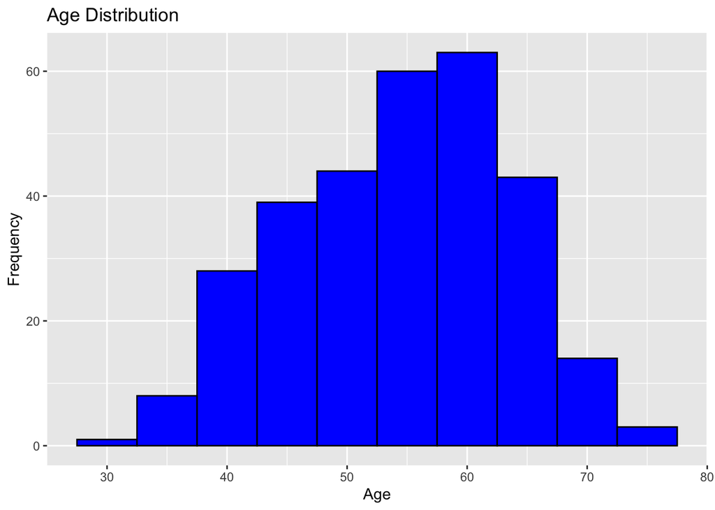

```r
ggplot(Heart_data, aes(x = age)) +
  geom_histogram(binwidth = 5, fill = "blue", color = "black") +
  ggtitle("Age Distribution") +
  xlab("Age") +
  ylab("Frequency")
```

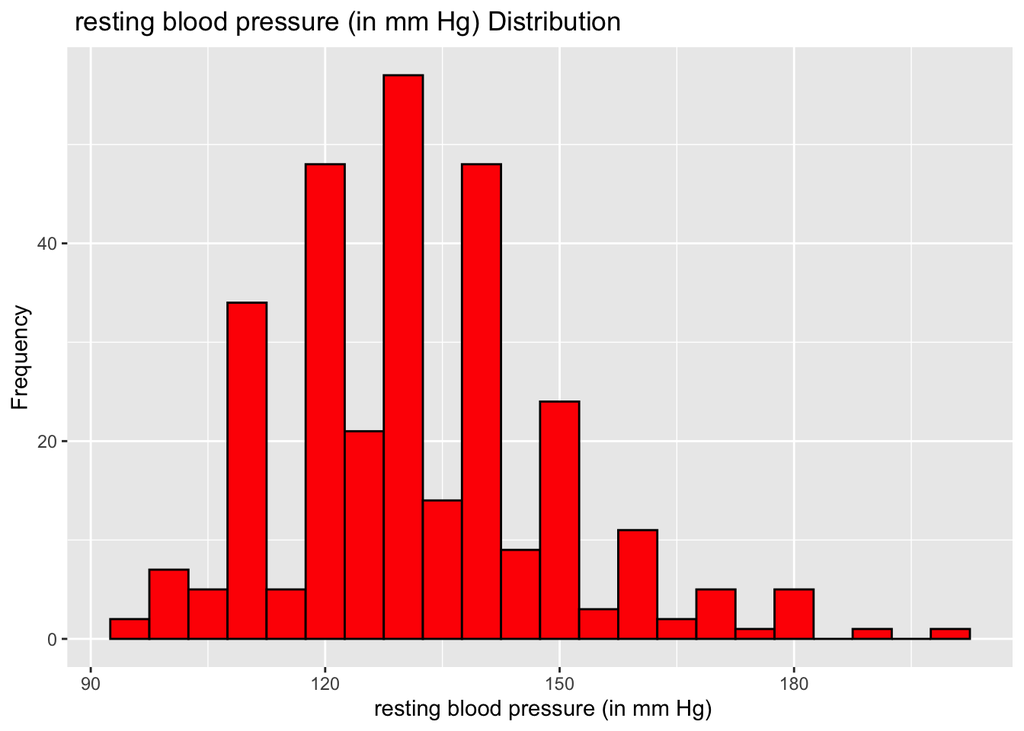

```r
ggplot(Heart_data, aes(x = trtbps)) +
  geom_histogram(binwidth = 5, fill = "red", color = "black") +
  ggtitle(" resting blood pressure (in mm Hg) Distribution") +
  xlab(" resting blood pressure (in mm Hg)") +
  ylab("Frequency")
```

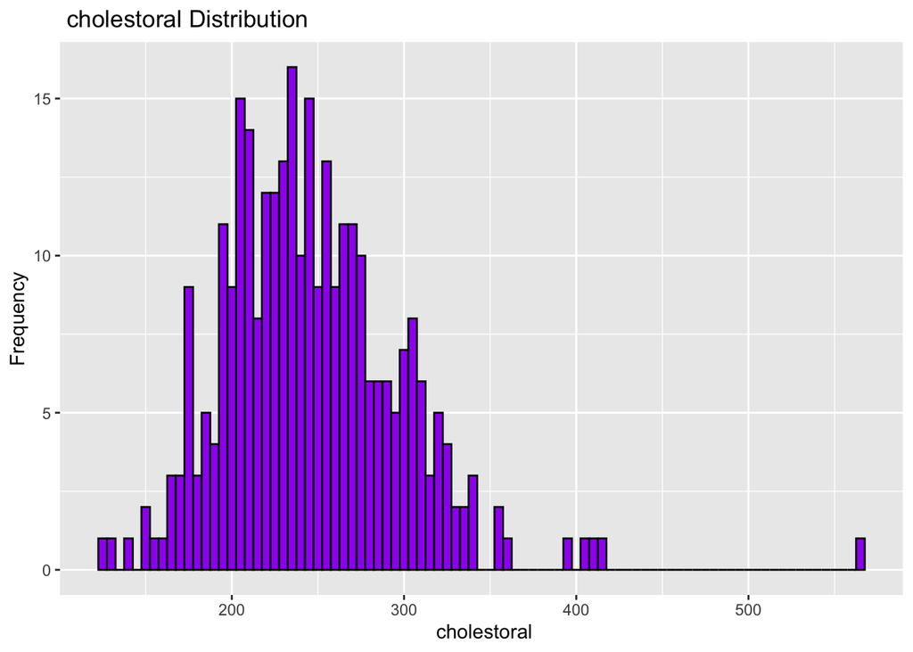

```r
ggplot(Heart_data, aes(x = chol)) +
  geom_histogram(binwidth = 5, fill = "purple", color = "black") +
  ggtitle(" cholestoral Distribution") +
  xlab(" cholestoral") +
  ylab("Frequency")
```

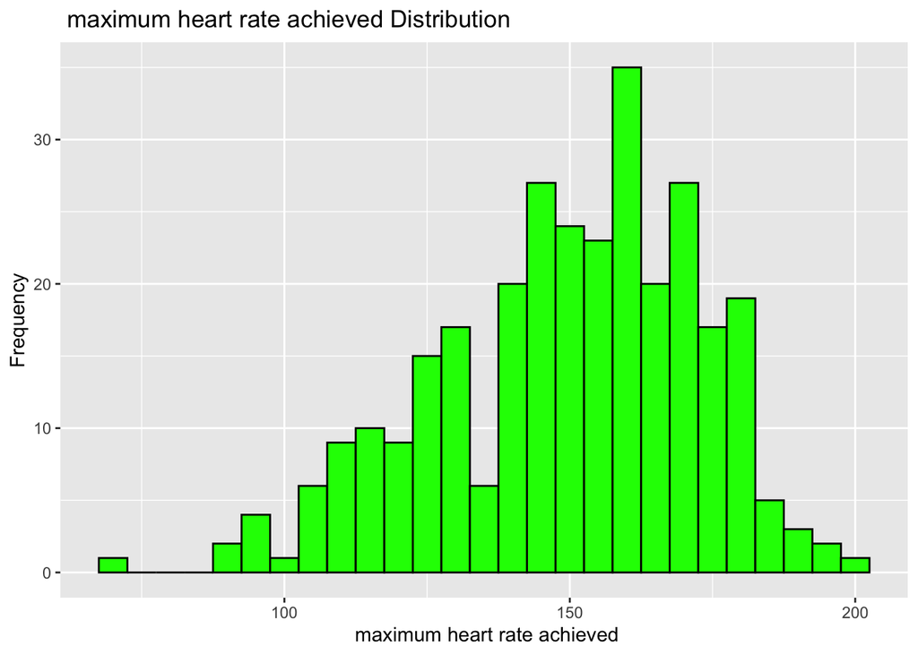

```r
ggplot(Heart_data, aes(x = thalachh)) +
  geom_histogram(binwidth = 5, fill = "green", color = "black") +
  ggtitle(" maximum heart rate achieved Distribution") +
  xlab(" maximum heart rate achieved") +
  ylab("Frequency")
```

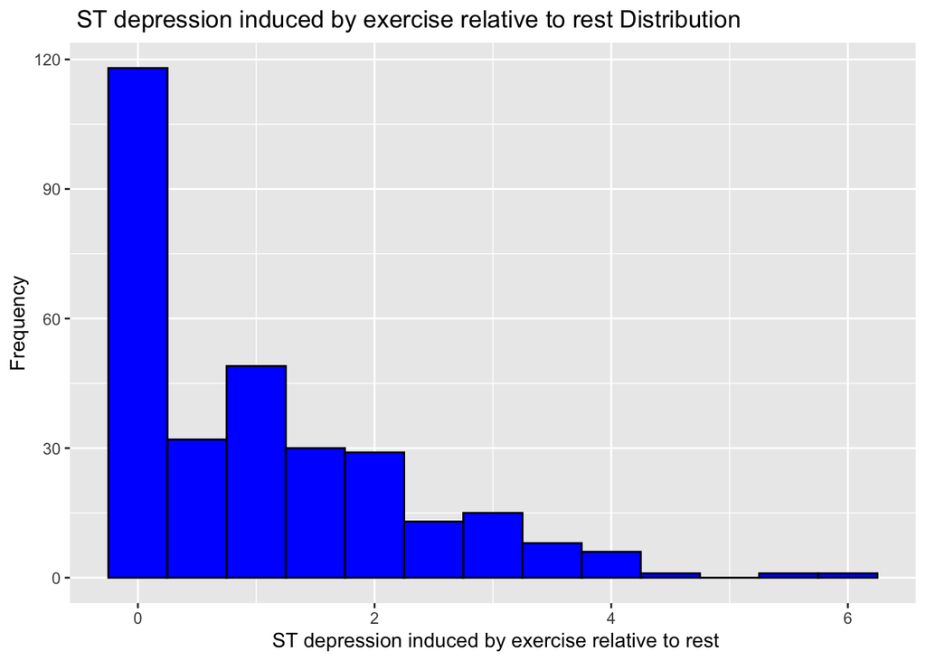

```r
ggplot(Heart_data, aes(x = oldpeak)) +
  geom_histogram(binwidth = 0.5, fill = "blue", color = "black") +
  ggtitle(" ST depression induced by exercise relative to rest Distribution") +
  xlab(" ST depression induced by exercise relative to rest") +
  ylab("Frequency")
```

#### Analysis Outputs(1)

##### Cholesterol Variable

- Cholesterol value in most patients is between 200-and 280.
- Values after 380 can be considered as outliers.

##### Thalach Variable

- The maximum heart rate achieved in most patients is between 145-and 170.
- In particular, The values before 80 can be considered outliers.

##### Oldpeak Variable

- Values of the vast majority of patients in the variable range from 0 to 1.5.
- Especially values after 2.5 can be considered as outliers.

#### 4.1.2 Categorical Variables(Analysis with **Pie Chart**)

```r
categoric_var
```

```
## [1] "sex"     "cp"      "fbs"     "restecg" "exng"    "slp"     "caa"
## [8] "thall"   "output"
```

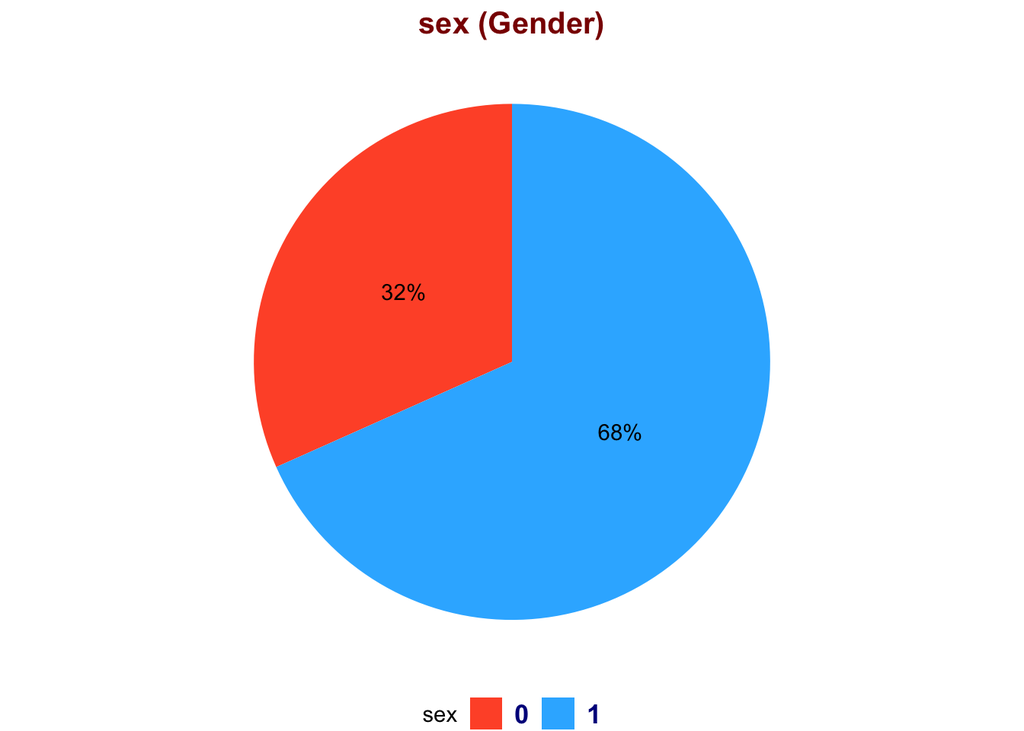

```r
heart_data_summary_sex <- Heart_data %>%
  count(sex) %>%
  mutate(perc = n / sum(n))

ggplot(heart_data_summary_sex, aes(x = "", y = n, fill = factor(sex))) +
  geom_bar(stat = "identity", width = 1) +
  coord_polar(theta = "y") +
  geom_text(aes(label = scales::percent(perc)), position = position_stack(vjust = 0.5)) +
  scale_fill_manual(values = c("#FF5733", "#33B5FF")) +
  labs(title = "sex (Gender)", fill = "sex") +
  theme_void() +
  theme(legend.position = "bottom",
        plot.title = element_text(hjust = 0.5, color = "darkred", size = 15, face = "bold"),
        legend.text = element_text(color = "darkblue", size = 13, face = "bold"))
```

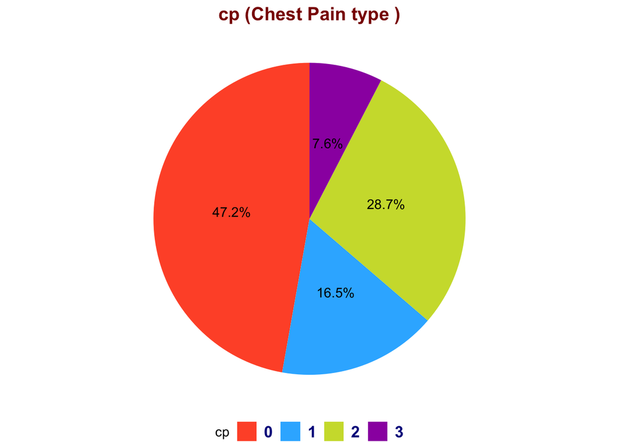

```r
heart_data_summary_cp <- Heart_data %>%
  count(cp) %>%
  mutate(perc = n / sum(n))

colors <- c("#FF5733", "#33B5FF", "#CDDC39", "#9C27B0")


# 绘制饼图
ggplot(heart_data_summary_cp, aes(x = "", y = n, fill = factor(cp))) +
  geom_bar(stat = "identity", width = 1) +
  coord_polar(theta = "y") +
  geom_text(aes(label = scales::percent(perc)), position = position_stack(vjust = 0.5)) +
  scale_fill_manual(values = colors) +
  labs(title = "cp (Chest Pain type )", fill = "cp") +
  theme_void() +
  theme(legend.position = "bottom",
        plot.title = element_text(hjust = 0.5, color = "darkred", size = 15, face = "bold"),
        legend.text = element_text(color = "darkblue", size = 13, face = "bold"))
```

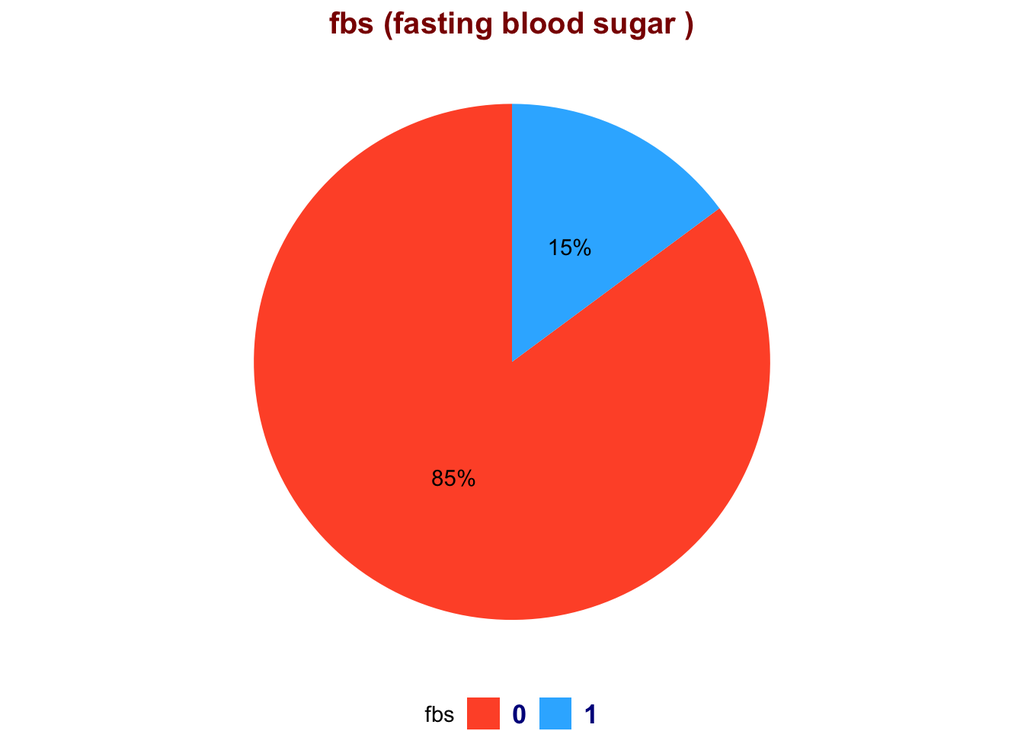

```r
heart_data_summary_fbs <- Heart_data %>%
  count(fbs) %>%
  mutate(perc = n / sum(n))

colors <- c("#FF5733", "#33B5FF")


# 绘制饼图
ggplot(heart_data_summary_fbs, aes(x = "", y = n, fill = factor(fbs))) +
  geom_bar(stat = "identity", width = 1) +
  coord_polar(theta = "y") +
  geom_text(aes(label = scales::percent(perc)), position = position_stack(vjust = 0.5)) +
  scale_fill_manual(values = colors) +
  labs(title = "fbs (fasting blood sugar )", fill = "fbs") +
  theme_void() +
  theme(legend.position = "bottom",
        plot.title = element_text(hjust = 0.5, color = "darkred", size = 15, face = "bold"),
        legend.text = element_text(color = "darkblue", size = 13, face = "bold"))
```